# Assignment Final

01.09.2023

Option 2

My public repository can be found on https://github.com/heySonia666/472-final-project.git

Introduction:

This research aims to address the characteristics and factors that differ between MPs who tend to ask questions about the economy and those who tend to ask questions about health and welfare. To answer this question, take the following steps: 1) Define economic issues and health and welfare issues and obtain relevant data from Oral and written Service API; 2) Gather the information of MPs of the House of Commons associated with the above data; 3) Get detailed MPs information from Members’ API; 4) Conduct analysis.

Data: Since economic issues and health and welfare issues do not have fixed definitions in the provided database, this project obtains the data of these two parts in the following ways: As the answering party of the question has a clear affiliation with the organization, it can “back infer” the information of the asking party from the economic, health and welfare related organizations. The institution name can be seen below in the code.

Then the relevant data is crawled from the API of Oral and Written Questions, including a series of information such as the ID number of the MPs who asked the question. When climbing, the parameters were set respectively, including setting the house as the House of Commons in written questions, setting the number of obtained to 5000 automatically in the system, expanding the information of MPs, setting the number of obtained in oral questions, etc. Project further extracts the ID number of MPs in the above obtained information, and further crawled into the Member API to obtain expanded data about MPs.

```
## # A tibble: 812 × 6
##    row      id isIndependentParty Party membershipStartDate gender
##    <chr> <int> <lgl>              <int> <chr>               <chr>
##  1 1      4597 FALSE                  4 2017-06-08T00:00:00 F
##  2 2      3943 TRUE                   8 2010-05-06T00:00:00 M
##  3 3      4614 FALSE                 15 2017-06-08T00:00:00 M
##  4 4      4358 FALSE                  4 2015-05-07T00:00:00 F
##  5 5      4092 FALSE                  4 2010-05-06T00:00:00 M
##  6 6      4446 FALSE                  4 2015-05-07T00:00:00 M
##  7 7      1501 FALSE                 15 2005-05-05T00:00:00 F
##  8 8      4667 FALSE                 15 2017-06-08T00:00:00 M
##  9 9      4371 FALSE                 29 2015-05-07T00:00:00 M
## 10 10     4470 FALSE                 29 2015-05-07T00:00:00 M
## # ℹ 802 more rows
```

```
## # A tibble: 511 × 6
##    row      id isIndependentParty Party membershipStartDate gender
##    <chr> <int> <lgl>              <int> <chr>               <chr>
##  1 1        39 FALSE                  4 1992-04-09T00:00:00 M
##  2 2      4041 FALSE                  4 2010-05-06T00:00:00 M
##  3 3      4509 FALSE                  4 2015-05-07T00:00:00 M
##  4 4      4464 FALSE                 15 2015-05-07T00:00:00 F
##  5 5      1200 FALSE                  4 2001-06-07T00:00:00 M
##  6 6       308 FALSE                 15 1992-04-09T00:00:00 M
##  7 7      4365 FALSE                 29 2015-05-07T00:00:00 M
##  8 8      4466 FALSE                 29 2015-05-07T00:00:00 M
##  9 9      4531 FALSE                  4 2015-05-07T00:00:00 F
## 10 10     4651 FALSE                 15 2017-06-08T00:00:00 M
## # ℹ 501 more rows
```

Analysis:

Gender:

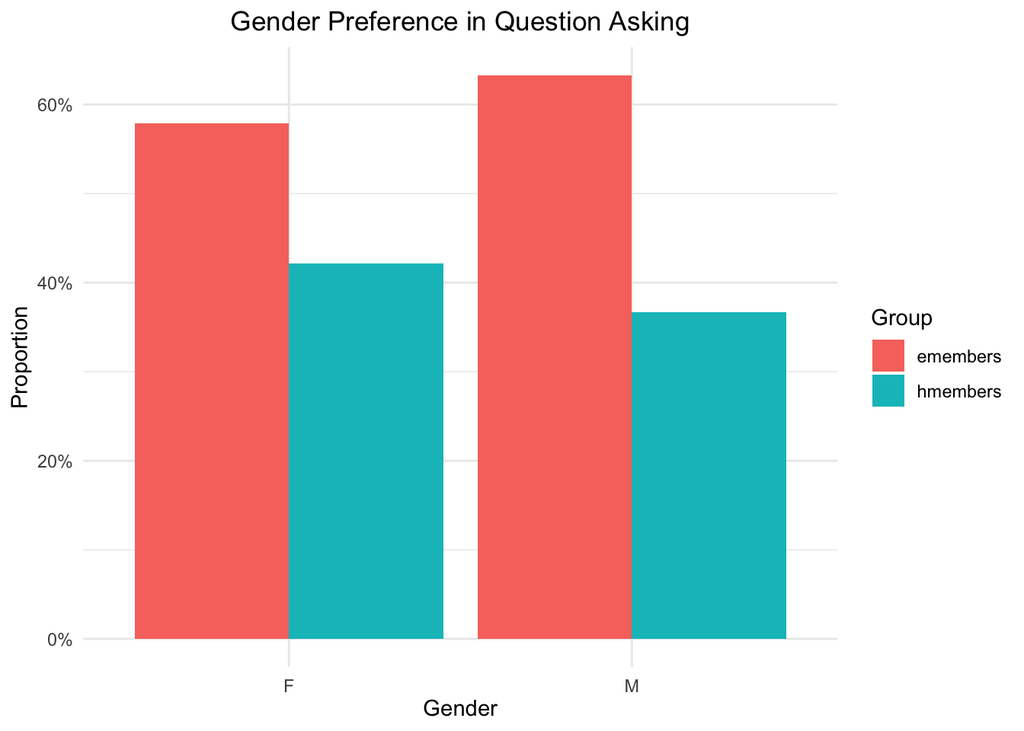

Observing the question-percentage in specific gender rather than gender-specific percentages in different questions is because that male and female MPs do not have the same number of people, as the data from House of Common Library shows that women make up 31% of parliamentarians (2022).

Party:

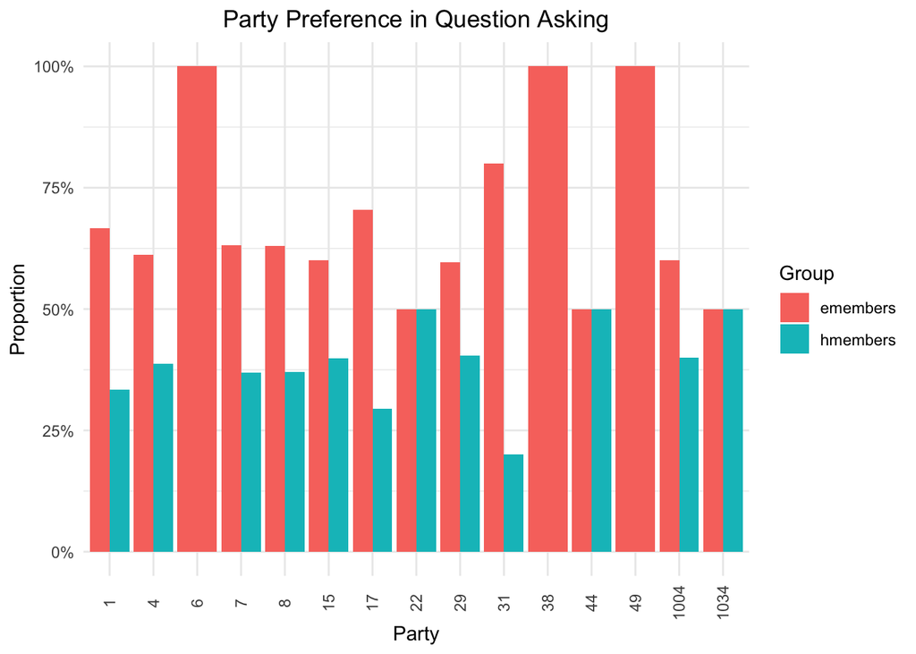

Notes: 1-Alliance, 4-Conservative, 6-Crossbench, 7-Democratic Unionist Party, 8-Independent, 15-Labour, 17-Liberal Democrat, 22-Plaid Cymru, 29-Scottish National Party, 31-Social Democratic & Labour Party, 38-Ulster Unionist Party, 44-Green Party, 49-Non-affiliated, 1004-The Independent Group for Change, 1034-Alba Party.

It needs to acknowledged that the presentation of the above proportions may be influenced by how many questions are asked as a result of party size, that certain deviation cannot be avoided.Table above reports MPs from Crossbench and Non-affiliated asked only about economic issues and not about health and welfare issues, while MPs from Plaid Cymru, Alba Party, and Green Party are questioning balanced. For main parties, the Conservatives and Labour, Conservatives show a higher priority for economic questions and a weaker preference for health and welfare than Labour.

Special time period:

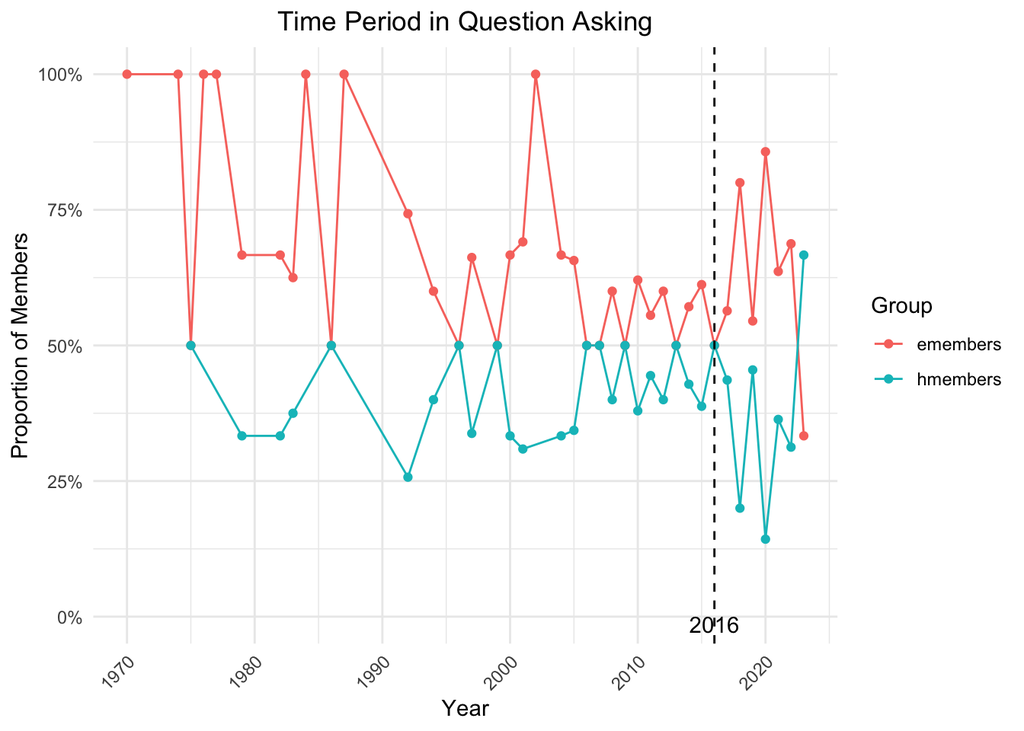

Combined analysis:

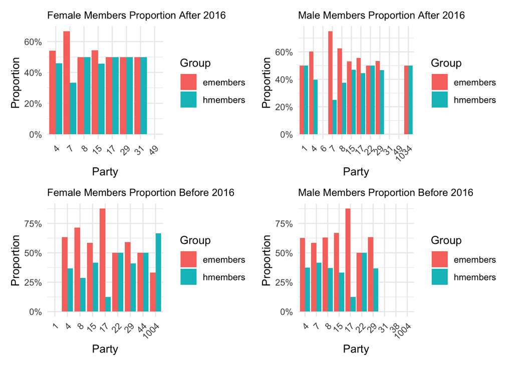

Table above reports,for women in the Conservative Party, their overall level of concern for economic issues declined after 2016, with a significant relative increase in concern for welfare. The questioning of female MPs from Liberal Democrat has a more pronounced influence by social and political conditions at a particular time. The change in the difference between Labour and Conservative men’s level of concern about economic and health issues was more pronounced after 2016, whereas it was not as obvious for women.

Conclusion: MPs asking about economic issues and health and welfare issues show certain differences in gender, party, and era background, where the details are shown in the above. However, it needs to be acknowledged that the above results may have certain biases, such as uneven party seats. This loophole needs to be filled in subsequent research.

Words:738

Bibliography (exclude from words limitation):

Crowe, E. (1986). The web of authority: Party loyalty and social control in the British House of Commons. Legislative Studies Quarterly, 161-185.

Raymond, C. D. (2017). Voting Behaviour on Free Votes: Simply a Matter of Preferences?. Parliamentary Affairs, 70(3), 489-506.

Wolbrecht, C., & Campbell, D. E. (2007). Leading by example: Female members of parliament as political role models. American Journal of Political Science, 51(4), 921-939.

Women in politics and public life - house of commons library. (n.d.). https://commonslibrary.parliament.uk/research-briefings/sn01250/

## Appendix: All code in this assignment

```r
# this chunk contains code that sets global options for the entire .Rmd.
# we use include=FALSE to suppress it from the top of the document, but it will still appear in the appendix.

knitr::opts_chunk$set(echo = FALSE) # actually set the global chunk options.
# we set echo=FALSE to suppress code such that it by default does not appear throughout the document.
# note: this is different from .Rmd default
library(httr)
library(jsonlite)
library(dplyr)

# Function to get data from an API endpoint
get_data_from_api <- function(url) {
  response <- GET(url)
  if (status_code(response) == 200) {
    data <- content(response, "text")
    return(fromJSON(data))
  } else {
    print(paste("Failed to get data from", url))
    return(NULL)
  }
}


# API endpoints
# The following institutions are selected as sources of acquisition：Department for Business(201), Energy and Industrial Strategy(202), Department for International Trade(214), Department for Business and Trade, Department for Business(26), Innovation and Skills,Department of Health and Social Care(17), Department for Work and Pensions(29)

written_h_url1 <- "https://questions-statements-api.parliament.uk/api/writtenquestions/questions?answeringBodies=17&house=Commons&take=5000"

written_h_url2 <- "https://questions-statements-api.parliament.uk/api/writtenquestions/questions?answeringBodies=29&house=Commons&take=5000"


written_e_url1 <- "https://questions-statements-api.parliament.uk/api/writtenquestions/questions?answeringBodies=201&house=Commons&take=5000"

written_e_url2 <- "https://questions-statements-api.parliament.uk/api/writtenquestions/questions?answeringBodies=202&house=Commons&take=5000"

written_e_url3 <- "https://questions-statements-api.parliament.uk/api/writtenquestions/questions?answeringBodies=214&house=Commons&take=5000"

written_e_url4 <- "https://questions-statements-api.parliament.uk/api/writtenquestions/questions?answeringBodies=26&house=Commons&take=5000"


# Fetch data
written_e_data1 <- get_data_from_api(written_e_url1)
written_e_data2 <- get_data_from_api(written_e_url2)
written_e_data3 <- get_data_from_api(written_e_url3)
written_e_data4 <- get_data_from_api(written_e_url4)
combined_written_e_data <- rbind(written_e_data1, written_e_data2,written_e_data3,written_e_data4)

written_h_data1 <- get_data_from_api(written_h_url1)
written_h_data2 <- get_data_from_api(written_h_url2)
combined_written_h_data <- rbind(written_h_data1, written_h_data2)

# API endpoints
oral_h_url1 <- "https://oralquestionsandmotions-api.parliament.uk/oralquestions/list?parameters.answeringBodyIds=17&parameters.take=100"

oral_h_url2 <- "https://oralquestionsandmotions-api.parliament.uk/oralquestions/list?parameters.answeringBodyIds=29&parameters.take=100"

oral_e_url1 <- "https://oralquestionsandmotions-api.parliament.uk/oralquestions/list?parameters.answeringBodyIds=201&parameters.take=100"

oral_e_url2 <- "https://oralquestionsandmotions-api.parliament.uk/oralquestions/list?parameters.answeringBodyIds=202&parameters.take=100"

oral_e_url3 <- "https://oralquestionsandmotions-api.parliament.uk/oralquestions/list?parameters.answeringBodyIds=214&parameters.take=100"

oral_e_url4 <- "https://oralquestionsandmotions-api.parliament.uk/oralquestions/list?parameters.answeringBodyIds=26&parameters.take=100"

# Function to fetch data from a given URL
fetch_data <- function(url, max_records = 5000) {
  records <- list()
  page_size <- 100
  current_offset <- 0

  while (length(records) < max_records) {
    response <- GET(paste0(url, "&parameters.offset=", current_offset))
    if (status_code(response) == 200) {
      data <- fromJSON(content(response, "text"), flatten = TRUE)
      records <- c(records, data)
      current_offset <- current_offset + page_size
    } else {
      break # Stop if there's an error or no more data
    }

    if (length(data) < page_size) { # Break the loop if last page has less than page_size records
      break
    }
  }

  return(records[1:min(max_records, length(records))])
}

# URLs
oral_h_url1 <- "https://oralquestionsandmotions-api.parliament.uk/oralquestions/list?parameters.answeringBodyIds=17&parameters.take=100"
oral_h_url2 <- "https://oralquestionsandmotions-api.parliament.uk/oralquestions/list?parameters.answeringBodyIds=29&parameters.take=100"
oral_e_url1 <- "https://oralquestionsandmotions-api.parliament.uk/oralquestions/list?parameters.answeringBodyIds=201&parameters.take=100"
oral_e_url2 <- "https://oralquestionsandmotions-api.parliament.uk/oralquestions/list?parameters.answeringBodyIds=202&parameters.take=100"
oral_e_url3 <- "https://oralquestionsandmotions-api.parliament.uk/oralquestions/list?parameters.answeringBodyIds=214&parameters.take=100"
oral_e_url4 <- "https://oralquestionsandmotions-api.parliament.uk/oralquestions/list?parameters.answeringBodyIds=26&parameters.take=100"

# Fetching data from each URL
oral_h_data1 <- fetch_data(oral_h_url1)
oral_h_data2 <- fetch_data(oral_h_url2)
combined_oral_h_data <- rbind(oral_h_data1, oral_h_data2)

oral_e_data1 <- fetch_data(oral_e_url1)
oral_e_data2 <- fetch_data(oral_e_url2)
oral_e_data3 <- fetch_data(oral_e_url3)
oral_e_data4 <- fetch_data(oral_e_url4)
combined_oral_e_data <- rbind(oral_e_data1, oral_e_data2,oral_e_data3,oral_e_data4)


eids1 <- combined_oral_e_data[[17]]$AskingMemberId
eids2 <- combined_oral_e_data[[18]]$AskingMemberId
eids3 <- combined_oral_e_data[[19]]$AskingMemberId

eids4 <- combined_written_e_data[5][[1]]$value$askingMemberId
eids5 <- combined_written_e_data[6][[1]]$value$askingMemberId
eids6 <- combined_written_e_data[7][[1]]$value$askingMemberId
eids7 <- combined_written_e_data[8][[1]]$value$askingMemberId

eidall <- c(eids1,eids2,eids3,eids4,eids5,eids6,eids7)


hids1 <- combined_oral_h_data[[9]]$AskingMemberId
hids2 <- combined_oral_h_data[[10]]$AskingMemberId

hids3 <- combined_written_h_data[3][[1]]$value$askingMemberId
hids4 <- combined_written_h_data[4][[1]]$value$askingMemberId

hidall <- c(hids1,hids2,hids3,hids4)

# Use the unique function to remove duplicates
unique_eidall <- unique(eidall)
unique_hidall <- unique(hidall)
```

```r
library(pbapply)
library(tidyr)
library(purrr)
library(tibble)
library(httr)
library(jsonlite)
get_member_data <- function(ids) {
  base_url <- "https://members-api.parliament.uk/api/Members/"

  # Use pblapply instead of the for loop and add a progress bar
  results <- pblapply(ids, function(id) {
    # Build the full API URL
    url <- paste0(base_url, id)

    # Executing API requests
    response <- GET(url)

    if (status_code(response) == 200) {
      # Parse the JSON response and return the data
      data <- fromJSON(content(response, "text"), flatten = TRUE)
      return(data$value)
    } else {
      warning(paste("Failed to retrieve data for ID:", id))
      return(NULL)
    }
  })

  # Removes the NULL value from the list
  results <- Filter(Negate(is.null), results)

  return(results)
}

emember_data <- get_member_data(unique_eidall)
hmember_data <- get_member_data(unique_hidall)

#print(emember_data)
#print(hmember_data)

# Define a safe extraction function
safe_extract <- function(the_list, ...) {
  tryCatch(
    {
      pluck(the_list, ...)
    },
    error = function(e) { NA }
  )
}

emembers_df <- map_dfr(emember_data, function(member) {
  tibble(
    id = safe_extract(member, "id"),
    isIndependentParty = safe_extract(member, "latestParty", "isIndependentParty"),
    Party = safe_extract(member, "latestParty", "id"),
    membershipStartDate = safe_extract(member, "latestHouseMembership", "membershipStartDate"),
    gender = safe_extract(member, "gender"),
  )
}, .id = "row")

# Print the resulting data frame
print(emembers_df)

hmembers_df <- map_dfr(hmember_data, function(member) {
  tibble(
    id = safe_extract(member, "id"),
    isIndependentParty = safe_extract(member, "latestParty", "isIndependentParty"),
    Party = safe_extract(member, "latestParty", "id"),
    membershipStartDate = safe_extract(member, "latestHouseMembership", "membershipStartDate"),
    gender = safe_extract(member, "gender"),
  )
}, .id = "row")

# Print the resulting data frame
print(hmembers_df)
library(ggplot2)
library(dplyr)

# Combine the data frames first
combined_df <- bind_rows(
  emembers_df %>% mutate(Group = 'emembers'),
  hmembers_df %>% mutate(Group = 'hmembers')
)

# Calculate the gender proportions
gender_prop <- combined_df %>%
  count(gender, Group) %>%
  group_by(gender) %>%
  mutate(Proportion = n / sum(n)) %>%
  ungroup()

# Plotting the data with a centered title
ggplot(gender_prop, aes(x = gender, y = Proportion, fill = Group)) +
  geom_bar(stat = "identity", position = "dodge") +
  scale_y_continuous(labels = scales::percent_format()) +
  labs(title = "Gender Preference in Question Asking", x = 'Gender', y = 'Proportion', fill = 'Group') +
  theme_minimal() +
  theme(axis.text.x = element_text(angle = 0, vjust = 0.5),  # Ensure x-axis labels are straight
        plot.title = element_text(hjust = 0.5)) # Center the title
library(ggplot2)
library(dplyr)

# Combine the data frames first
combined_df <- bind_rows(
  emembers_df %>% mutate(Group = 'emembers'),
  hmembers_df %>% mutate(Group = 'hmembers')
)

# Calculate the party proportions
party_prop <- combined_df %>%
  count(Party, Group) %>%
  group_by(Party) %>%
  mutate(Proportion = n / sum(n)) %>%
  ungroup()

# Ensure Party is treated as a factor
party_prop$Party <- as.factor(party_prop$Party)

# Plotting the data with a centered title
ggplot(party_prop, aes(x = Party, y = Proportion, fill = Group)) +
  geom_bar(stat = "identity", position = "dodge") +
  scale_y_continuous(labels = scales::percent_format()) +
  labs(title = "Party Preference in Question Asking", x = 'Party', y = 'Proportion', fill = 'Group') +
  theme_minimal() +
  theme(axis.text.x = element_text(angle = 90, vjust = 0.5),  # Rotate x-axis labels for Party
        plot.title = element_text(hjust = 0.5)) # Center the title
library(ggplot2)
library(dplyr)
library(lubridate)

# Convert membershipStartDate to Date format
emembers_df$membershipStartDate <- as.Date(emembers_df$membershipStartDate)
hmembers_df$membershipStartDate <- as.Date(hmembers_df$membershipStartDate)

# Extract the year from the membershipStartDate
emembers_df$Year <- year(emembers_df$membershipStartDate)
hmembers_df$Year <- year(hmembers_df$membershipStartDate)

# Combine the data frames
combined_df <- bind_rows(
  emembers_df %>% mutate(Group = 'emembers'),
  hmembers_df %>% mutate(Group = 'hmembers')
)

# Calculate the counts for each year and group
yearly_counts <- combined_df %>%
  group_by(Year, Group) %>%
  summarise(n = n(), .groups = 'drop')

# Calculate proportions for each year
yearly_counts <- yearly_counts %>%
  group_by(Year) %>%
  mutate(Proportion = n / sum(n)) %>%
  ungroup()

# Plotting the data with a centered title
line_plot <- ggplot(yearly_counts, aes(x = Year, y = Proportion, group = Group, color = Group)) +
  geom_line() +
  geom_point() + # Add points to the line graph
  geom_vline(xintercept = 2016, linetype = "dashed", color = "black") +
  annotate("text", x = 2016, y = 0, label = "2016", vjust = 1, color = "black", angle = 0) +
  scale_y_continuous(labels = scales::percent_format()) +
  labs(title = "Time Period in Question Asking", x = 'Year', y = 'Proportion of Members', color = 'Group') +
  theme_minimal() +
  theme(axis.text.x = element_text(angle = 45, vjust = 1, hjust = 1),  # Tilt the x-axis labels
        plot.title = element_text(hjust = 0.5)) # Center the title

# Display the plot
print(line_plot)

library(ggplot2)
library(dplyr)
library(lubridate)

# Assume emembers_df and hmembers_df are already loaded and have the appropriate columns

# Function to classify dates into two periods
classify_period <- function(date) {
  if (year(date) < 2016) {
    'Before 2016'
  } else {
    'After 2016'
  }
}

# Convert membershipStartDate to Date and classify periods
emembers_df$membershipStartDate <- as.Date(emembers_df$membershipStartDate)
hmembers_df$membershipStartDate <- as.Date(hmembers_df$membershipStartDate)

emembers_df$Period <- sapply(emembers_df$membershipStartDate, classify_period)
hmembers_df$Period <- sapply(hmembers_df$membershipStartDate, classify_period)
```

```r
# Filter for female members after 2016 and ensure Party is treated as a factor
emembers_female <- emembers_df %>% filter(gender == "F" & Period == 'After 2016') %>% mutate(Party = as.factor(Party))
hmembers_female <- hmembers_df %>% filter(gender == "F" & Period == 'After 2016') %>% mutate(Party = as.factor(Party))

# Count by Party for emembers and hmembers
emembers_female_counts <- emembers_female %>% count(Party)
hmembers_female_counts <- hmembers_female %>% count(Party)

# Combine the counts and calculate proportions
combined_female_counts <- full_join(emembers_female_counts, hmembers_female_counts, by = "Party", suffix = c("_emembers", "_hmembers")) %>%
  mutate(Party = as.factor(Party),
         emembers = n_emembers / (n_emembers + n_hmembers),
         hmembers = n_hmembers / (n_emembers + n_hmembers))

# Melt the combined data for plotting with ggplot2
combined_female_melted <- reshape2::melt(combined_female_counts, id.vars = "Party", measure.vars = c("emembers", "hmembers"))

# Plot the data for females
female_plot <- ggplot(combined_female_melted, aes(x = Party, y = value, fill = variable)) +
  geom_bar(stat = "identity", position = "dodge") +
  scale_y_continuous(labels = scales::percent_format()) +
  labs(x = 'Party', y = 'Proportion', fill = 'Group',title = 'Female Members Proportion After 2016') +
  theme_minimal() +
  theme(axis.text.x = element_text(angle = 45, hjust = 1),
        plot.title = element_text(size = 10))


# Filter for male members after 2016 and ensure Party is treated as a factor
emembers_male <- emembers_df %>% filter(gender == "M" & Period == 'After 2016') %>% mutate(Party = as.factor(Party))
hmembers_male <- hmembers_df %>% filter(gender == "M" & Period == 'After 2016') %>% mutate(Party = as.factor(Party))

# Count by Party for emembers and hmembers
emembers_male_counts <- emembers_male %>% count(Party)
hmembers_male_counts <- hmembers_male %>% count(Party)

# Combine the counts and calculate proportions
combined_male_counts <- full_join(emembers_male_counts, hmembers_male_counts, by = "Party", suffix = c("_emembers", "_hmembers")) %>%
  mutate(Party = as.factor(Party),
         emembers = n_emembers / (n_emembers + n_hmembers),
         hmembers = n_hmembers / (n_emembers + n_hmembers))

# Melt the combined data for plotting with ggplot2
combined_male_melted <- reshape2::melt(combined_male_counts, id.vars = "Party", measure.vars = c("emembers", "hmembers"))

# Plot the data for males
male_plot <- ggplot(combined_male_melted, aes(x = Party, y = value, fill = variable)) +
  geom_bar(stat = "identity", position = "dodge") +
  scale_y_continuous(labels = scales::percent_format()) +
  labs(x = 'Party', y = 'Proportion', fill = 'Group',title = 'Male Members Proportion After 2016') +
  theme_minimal() +
  theme(axis.text.x = element_text(angle = 45, hjust = 1),
        plot.title = element_text(size = 10))

# Filter for female members before 2016 and ensure Party is treated as a factor
emembers_female_before <- emembers_df %>% filter(gender == "F" & Period == 'Before 2016') %>% mutate(Party = as.factor(Party))
hmembers_female_before <- hmembers_df %>% filter(gender == "F" & Period == 'Before 2016') %>% mutate(Party = as.factor(Party))

# Count by Party for emembers and hmembers
emembers_female_counts_before <- emembers_female_before %>% count(Party)
hmembers_female_counts_before <- hmembers_female_before %>% count(Party)

# Combine the counts and calculate proportions
combined_female_counts_before <- full_join(emembers_female_counts_before, hmembers_female_counts_before, by = "Party", suffix = c("_emembers", "_hmembers")) %>%
  mutate(Party = as.factor(Party),
         emembers = n_emembers / (n_emembers + n_hmembers),
         hmembers = n_hmembers / (n_emembers + n_hmembers))

# Melt the combined data for plotting with ggplot2
combined_female_melted_before <- reshape2::melt(combined_female_counts_before, id.vars = "Party", measure.vars = c("emembers", "hmembers"))

# Plot the data for females before 2016
female_plot_before <- ggplot(combined_female_melted_before, aes(x = Party, y = value, fill = variable)) +
  geom_bar(stat = "identity", position = "dodge") +
  scale_y_continuous(labels = scales::percent_format()) +
  labs(x = 'Party', y = 'Proportion', fill = 'Group', title = 'Female Members Proportion Before 2016') +
  theme_minimal() +
  theme(axis.text.x = element_text(angle = 45, hjust = 1),
        plot.title = element_text(size = 10))


# Filter for male members before 2016 and ensure Party is treated as a factor
emembers_male_before <- emembers_df %>% filter(gender == "M" & Period == 'Before 2016') %>% mutate(Party = as.factor(Party))
hmembers_male_before <- hmembers_df %>% filter(gender == "M" & Period == 'Before 2016') %>% mutate(Party = as.factor(Party))

# Count by Party for emembers and hmembers
emembers_male_counts_before <- emembers_male_before %>% count(Party)
hmembers_male_counts_before <- hmembers_male_before %>% count(Party)

# Combine the counts and calculate proportions
combined_male_counts_before <- full_join(emembers_male_counts_before, hmembers_male_counts_before, by = "Party", suffix = c("_emembers", "_hmembers")) %>%
  mutate(Party = as.factor(Party),
         emembers = n_emembers / (n_emembers + n_hmembers),
         hmembers = n_hmembers / (n_emembers + n_hmembers))

# Melt the combined data for plotting with ggplot2
combined_male_melted_before <- reshape2::melt(combined_male_counts_before, id.vars = "Party", measure.vars = c("emembers", "hmembers"))

# Plot the data for males before 2016
male_plot_before <- ggplot(combined_male_melted_before, aes(x = Party, y = value, fill = variable)) +
  geom_bar(stat = "identity", position = "dodge") +
  scale_y_continuous(labels = scales::percent_format()) +
  labs(x = 'Party', y = 'Proportion', fill = 'Group', title = 'Male Members Proportion Before 2016') +
  theme_minimal() +
  theme(axis.text.x = element_text(angle = 45, hjust = 1),
        plot.title = element_text(size = 10))


library(patchwork)
```

```r
# Combine plots
combined_plot <- (female_plot | male_plot) /
                 (female_plot_before | male_plot_before)

# show the combined plot
combined_plot
# this chunk generates the complete code appendix.
# eval=FALSE tells R not to run (``evaluate'') the code here (it was already run before).
```